+++ title = “Getting Feedback from Student Reflection” author = “Kate Pyper” date = “2020-08-03” tags = [“Teaching”,“Feedback”,“Reflection”] +++

In my quest to provide a good virtual classroom, I’ve recently been thinking a lot about feedback. I know that it is important for me to give students timely and useful feedback, and I’m building that in to various aspects of the class. I’ve recently been focussed on getting useful feedback from students.

I remember being an undergrad student and being asked at the end of a course to fill out a feedback form. I also remember finding that really annoying because I don’t get to see the benefit of any of that feedback. I wanted to make the effort to change things that students needed help with as the course progressed.

In my regression class last year I tried to collect more feedback, and asked students to fill in a short (four questions) questionnaire each week online. This wasn’t particularly successful - out of a class of around 200 I would get around 10 responses each week. However, I will say that the responses the I did get helped me to either make useful changes to the course material (e.g. adding video content or additional exercises where people highlighted issues) or to address why I was teaching things in a particular way.

I’m planning on still seeking weekly feedback, but I want this feedback to feel more student centred and I want to encourage students to reflect on how they feel about the course material. In the feedback, I want to focus on the material rather than my performance, again trying to encourage the students to think about themselves.

## Feedback Structure

I’ve used the [feedback module](https://docs.moodle.org/39/en/Feedback_activity) in moodle to collect responses. The responses will be anonymous, and the questions will be split into two sections; one part that I won’t look at in detail, another that I will look at in detail.

### Part 1: Reflection on Effort and Understanding

The first section, which I only plan on looking at over the class as a whole, asks the students to reflect on how much effort they have put in over the week and how they would rate their understanding. I’m hoping that the anonymity of the feedback module will encourage students to think honestly about this.

This first part consists of two multiple choice questions as shown below:

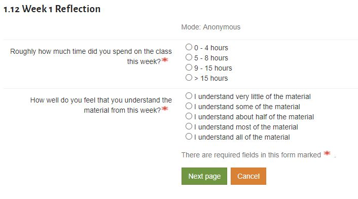

For the first question, it is relevant to note that I’ve designed the online materials to take somewhere between 6 and 8 hours, to keep it roughly in line with the 6 hours of contact time that they would get if they were taking the class face-to-face. The course is a 20 credit model spread over 10 weeks, so in theory the students would be expected to spend 20 hours per week on the class.

Since this course is aimed at MSc students, I’m not particularly concerned with individual time management, but would be interested to see how much time students spend on the materials overall. I may reconsider this when I modify this course for the second year undergraduates.

The second question is about the student reflecting on their own understanding. I’m asking students to use this as a reflection tool and this isn’t something that I’ll look into beyond the overall class level. I’m also considering adding my contact details to this question to encourage students who would place their understanding in the bottom three categories to contact me to arrange a meeting.

### Part 2: Reflection on the Materials

The second section will ask the students to reflect on the materials. There will be four questions (technically one is a sub-question) which allow the students to identify areas that they would like more information, areas that they felt were good and areas where they feel that some improvement could be made. These can be seen below:

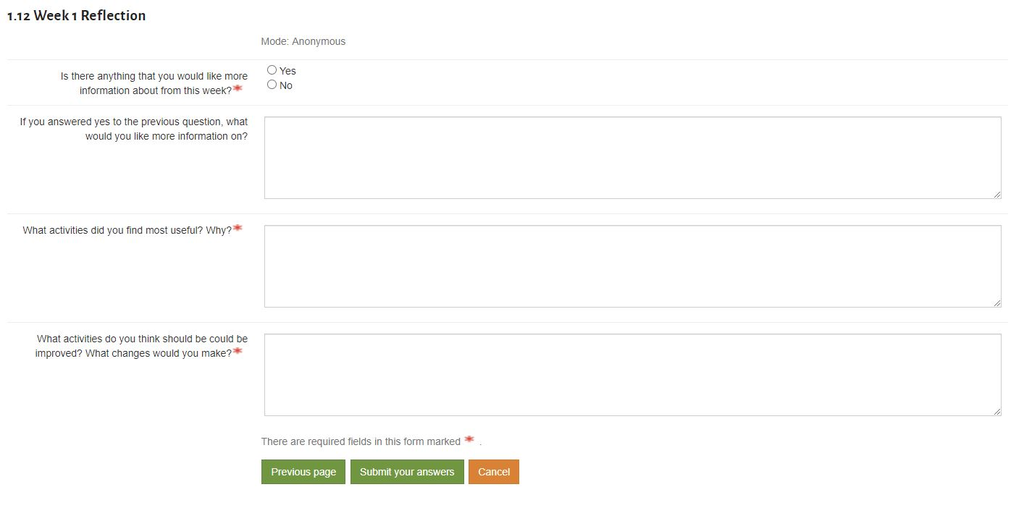

I have tried to be careful with the wording of these questions, so that they take me out of the equation and put the ownership onto the students and what they want.

The first two questions are grouped together, and identify the concepts that students want more information about. This will allow me to update materials where appropriate, or add information to the Q&A thread discussed [in the previous post]({{< relref “../First-Step-to-Blended/First-Step-to-Blended.md” >}})